# Gas model — BVAR with stochastic volatility and model-based outliers

### 10.2 MCMC effective sample size and autocorrelation

MCMC diagnostics

|  | posterior_mean | posterior_sd | ESS | MCSE_mean | MCSE_over_sd |
| --- | --- | --- | --- | --- | --- |
| p_outlier[gas_pre_tax] | 0.09 | 0.02 | 41.37 | 3.55 × 10⁻³ | 0.16 |
| phi[gas_pre_tax] | 0.02 | 0.01 | 42.32 | 1.76 × 10⁻³ | 0.15 |
| log likelihood | -791.02 | 15.68 | 45.34 | 2.33 | 0.15 |
| phi[natural_gas_wholesale] | 0.19 | 0.06 | 142.19 | 5.05 × 10⁻³ | 0.08 |
| A[gas_pre_tax,natural_gas_wholesale] | -0.02 | 9.86 × 10⁻³ | 206.19 | 6.87 × 10⁻⁴ | 0.07 |
| spectral radius | 0.81 | 0.03 | 318.27 | 1.45 × 10⁻³ | 0.06 |
| own L1[gas_pre_tax] | 0.12 | 0.03 | 411.43 | 1.68 × 10⁻³ | 0.05 |
| p_outlier[natural_gas_wholesale] | 9.78 × 10⁻³ | 6.05 × 10⁻³ | 860.16 | 2.06 × 10⁻⁴ | 0.03 |
| own L1[natural_gas_wholesale] | 0.10 | 0.07 | 994.96 | 2.11 × 10⁻³ | 0.03 |

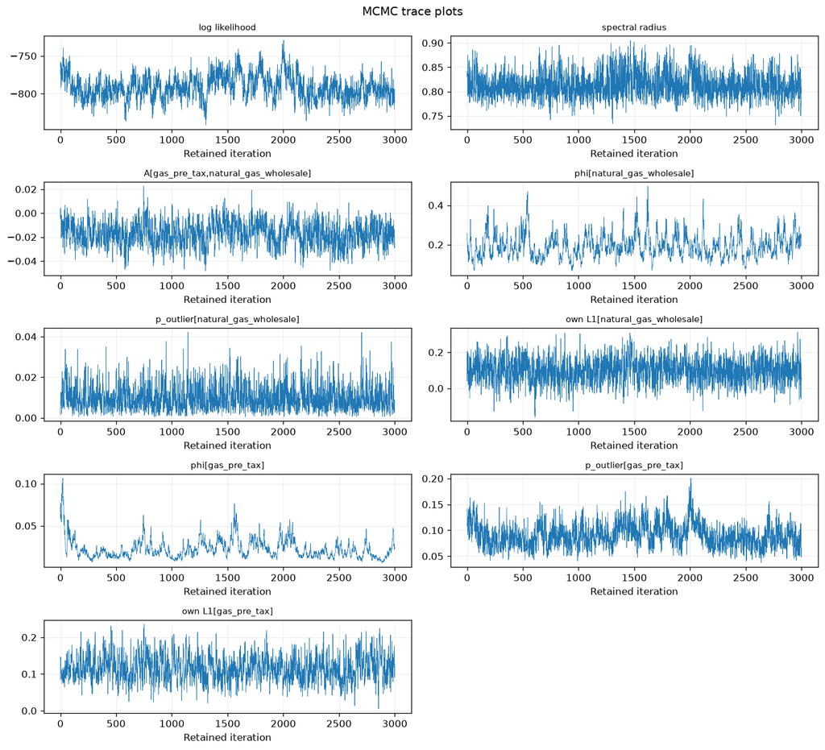

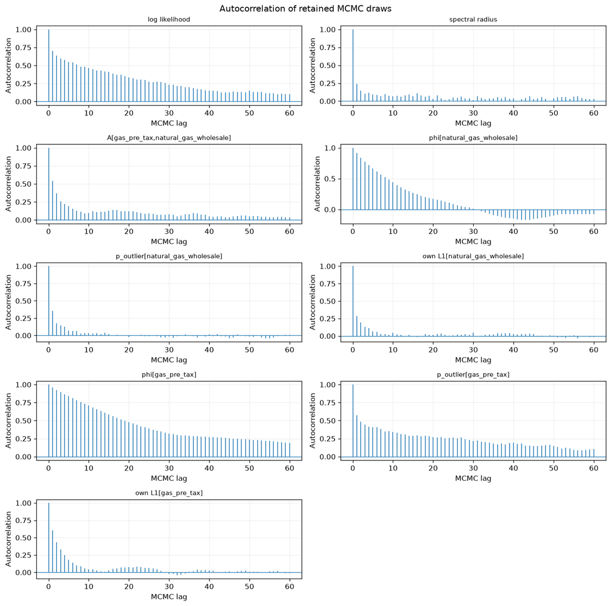

```python
diagnostic_table = mcmc_diagnostics(result)
display(style_numeric_table(diagnostic_table.sort_values("ESS"), caption="MCMC diagnostics"))
plot_trace_grid(result)
plot_chain_acf_grid(result, nlags=60)
plt.show()
```

Phi's traces and autocorellation are not great. Suggest to move to ASCI sampling method.

### 10.3 Stability

VAR stability diagnostics

|  | value |
| --- | --- |
| retained_draws | 3000.00 |
| median_spectral_radius | 0.81 |
| q95_spectral_radius | 0.86 |
| maximum_spectral_radius | 0.91 |
| retained_unstable_share | 0.00 |
| B_total_proposals | 6000.00 |
| B_unstable_proposals | 0.00 |
| B_instability_rejection_rate | 0.00 |

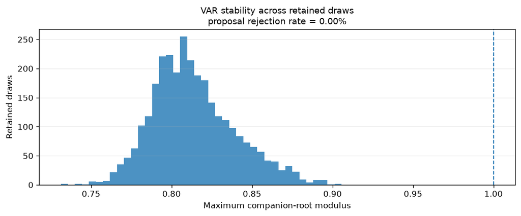

```python
display(style_numeric_table(
    stability_diagnostics(result).to_frame("value"),
    caption="VAR stability diagnostics",
))
plot_spectral_radius(result)
plt.show()
```

### 10.4 Posterior predictive checks

```
Posterior predictive checks: natural_gas_wholesale
```

Posterior predictive checks — natural_gas_wholesale

|  | observed | replicated_median | replicated_q05 | replicated_q95 |
| --- | --- | --- | --- | --- |
| natural_gas_wholesale: mean | 0.13 | 0.10 | -1.63 | 1.66 |
| natural_gas_wholesale: sd | 11.79 | 10.44 | 7.10 | 23.38 |
| natural_gas_wholesale: maximum_absolute | 117.89 | 88.78 | 47.30 | 333.24 |

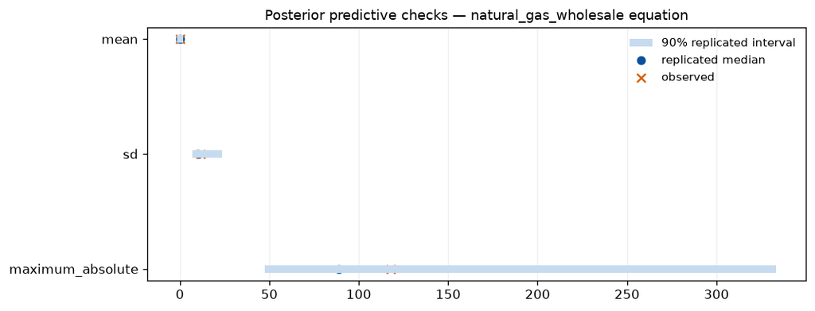

```
Posterior predictive checks: gas_pre_tax
```

Posterior predictive checks — gas_pre_tax

|  | observed | replicated_median | replicated_q05 | replicated_q95 |
| --- | --- | --- | --- | --- |
| gas_pre_tax: mean | 0.18 | 0.15 | -0.34 | 0.64 |
| gas_pre_tax: sd | 2.44 | 2.65 | 1.76 | 4.13 |
| gas_pre_tax: maximum_absolute | 19.74 | 23.89 | 12.35 | 42.23 |

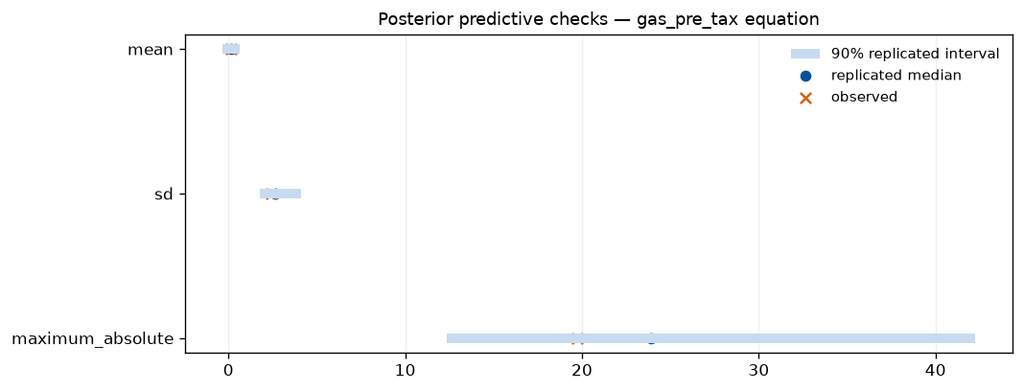

```python
ppc_summary, ppc_draws = posterior_predictive_statistics(
    result,
    n_draws=min(300, result["n_draws"]),
    seed=2027,
)
for equation in VARIABLES:
    print(f"\nPosterior predictive checks: {equation}")
    equation_rows = ppc_summary.loc[
        [str(index).startswith(f"{equation}:") for index in ppc_summary.index]
    ]
    display(style_numeric_table(
        equation_rows,
        caption=f"Posterior predictive checks — {equation}",
    ))
    plot_posterior_predictive_check(ppc_summary, equation=equation)
    plt.show()
```

## 11. Sensitivity analysis (if time))

The baseline result should not be treated as final until the following specifications have been compared:

1. **Recursive ordering:** `[natural_gas_wholesale, gas_pre_tax]` versus the reverse ordering. This changes the structural shocks and their stochastic volatilities.
2. **Volatility prior:** alternative values for `phi_prior_mean` and `phi_prior_df`.
3. **Outlier prior:** alternative prior frequencies and concentrations around one outlier every four years.
4. **Future outliers:** predictive densities with `simulate_future_outliers=True` and with future scales fixed to one.
5. **Minnesota tightness:** a grid for `lambda1` and `lambda2`.
6. **Forecast scenario:** constant wholesale price, +10% permanent price, and externally supplied conditioning paths.

These are separate model runs. They should use the same vintage, same forecast origin, and common random seeds where possible.